# Quick introduction to foodingraph

Victor Gasque, Cecilia Samieri, Boris Hejblum

```r
library(foodingraph)
```

## Introduction

A simple R package to infer food networks from categorical and binary variables.

Displays a weighted undirected graph from an adjacency matrix. Can perform confidence-interval bootstrap inference with mutual information or maximal information coefficient.

#### How it works

For example, For each pairwise association, if the 99th percentile of the simulated CI is higher than the 1th percentile of the sample bootstrap distribution, the edge is removed.

From the infered adjacency matrix, the package can then display the graph using `ggplot2`[^3], `igraph`[^4] and `ggraph`[^5].

See R documentation for more information.

## Example data set

For the purpose of this example, I invented some food intakes data on $n=13$ subjects and $f=8$ food groups : $o=6$ ordinally-encoded (from 0 to 13) and $b=2$ binary-encoded (0 or 1). Therefore, do not expect these examples to reflect reality.

```r
# Food intakes (ordinaly- or binary-encoded)
obs_data <- data.frame(
#| Foods | Subject 1   2   3   4   5   6   7   8   9  10  11  12  13  |
#|-------|------------------------------------------------------------|
  alcohol_cat  = c(8,  1,  3,  0, 10,  5,  1, 10,  2,  8,  1,  3,  9),
  bread_cat    = c(7,  4,  3,  4,  0,  9,  4,  5,  7,  3,  4,  0,  9),
  coffee_cat   = c(3,  6,  6,  6,  2,  3,  5,  8,  8,  6,  6,  2,  3),
  duck_cat     = c(0,  3,  1,  0,  0,  2, 13,  1,  0,  0,  2, 13,  1),
  eggs_cat     = c(5,  5,  4,  5,  8,  8,  6,  9,  6,  8,  2,  3,  1),
  fruit_cat    = c(1,  7,  5,  8,  2,  3,  1,  0,  7,  7,  5,  8,  2),
  gin_bin      = c(1,  0,  1,  0,  1,  0,  0,  1,  0,  0,  1,  0,  1),
  ham_bin      = c(1,  1,  1,  1,  1,  1,  1,  0,  1,  1,  1,  0,  1)
)

head(obs_data)
```

```
#>   alcohol_cat bread_cat coffee_cat duck_cat eggs_cat fruit_cat gin_bin ham_bin
#> 1           8         7          3        0        5         1       1       1
#> 2           1         4          6        3        5         7       0       1
#> 3           3         3          6        1        4         5       1       1
#> 4           0         4          6        0        5         8       0       1
#> 5          10         0          2        0        8         2       1       1
#> 6           5         9          3        2        8         3       0       1
```

```r
# The legend for the graph
legend <- data.frame(
  name   = colnames(obs_data),
  title  = c("Alcohol", "Bread",   "Coffee",    "Duck",    "Eggs", "Fruit", "Gin",     "Ham"),
  family = c("Alcohol", "Cereals", "Beverages", "Poultry", "Eggs", "Fruit", "Alcohol", "Meats")
)

# Transform family intro factors?
```

Now let’s calculate the maximal information coefficient[^6] adjacency matrix, with the `foodingraph` function `mic_adj_matrix`.

```r
adjacency_matrix <-  mic_adj_matrix(obs_data)
```

## Network inference

This step is optional. If you want to visualize the network, jump to Network visualization

### Arbitrary threshold

Foodingraph allows to select edges on the basis of a threshold value in the adjacency matrix. It can either be applied to the adjacency matrix by the functions `graph_from_matrix()` or `links_nodes_from_mat()`, with two parameters:

1. `threshold` (default is 0) : the threshold value
2. `abs_threshold` (bool, default TRUE) : if the threshold should apply to the absolute values of the edges or not. If TRUE, it will *not* convert the values of the adjacency matrix to absolute values, only compare the threshold to the absolute values.

### Confidence-interval bootstrap inference

Foodingraph allows to perform confidence-interval (CI) bootstrap inference, by comparing the CI bootstrap of simulated independent data to the CI bootstrap of each pairwise association of the dataset. Two methods to calculate the CI bootstrap exist : mutual information[^7] or maximal information coefficient[^8].

**NOTE** If you want to use mutual information, be sure to install the `minet` package available on Bioconductor. It will not be automatically downloaded when installing foodingraph.

#### CI bootstrap of independent simulated data

Let’s start by simulating independent data. As our dataset is comprised of ordinal and binary variables, we will simulate independent :

- pairwise ordinal variables
- pairwise binary variables
- pairwise ordinal & binary variables.

This will allow to compare each pairwise association of the dataset to the corresponding type of threshold.

For this example, we will use MIC.

```r
# Ordinal vs. ordinal
thresh_ord_ord <- boot_simulated_cat_bin("cat", method = "mic", size = 500)
```

```
#> [1] "Confidence-interval bootstrap on simulated independent variables of type: cat"
#> [1] "Number of simulations: 10"
#> [1] "Number of bootstraps per simulations: 5000"
#> [1] "Sample size for each simulation: 500"
#> [1] "Contigency table of the simulated data:"
#>     var2
#> var1   0   1   2   3   4   5   6   7
#>    0 107  60  33  21   4   0   0   1
#>    1  62  47  17   9   5   1   0   0
#>    2  33  20  12   2   6   1   3   0
#>    3  12   7   5   3   2   0   0   0
#>    4   6   5   6   0   1   0   0   0
#>    5   6   2   0   0   0   0   0   0
#>    6   0   1   0   0   0   0   0   0
#> [1] "Simulation 1 : 0.0314765637409941"
#> [1] "Simulation 2 : 0.0317311699533376"
#> [1] "Simulation 3 : 0.0319656714072953"
#> [1] "Simulation 4 : 0.0328531681354845"
#> [1] "Simulation 5 : 0.0325620643858301"
#> [1] "Simulation 6 : 0.0321092249779656"
#> [1] "Simulation 7 : 0.0316157986926035"
#> [1] "Simulation 8 : 0.0321165857357385"
#> [1] "Simulation 9 : 0.0325308962473776"
#> [1] "Simulation 10 : 0.0321832348688438"
#> [1] "Mean of the percentiles: 0.0321144378145471"
```

```r
# Binary vs. binary
thresh_bin_bin <- boot_simulated_cat_bin("bin", method = "mic", size = 500)
```

```
#> [1] "Confidence-interval bootstrap on simulated independent variables of type: bin"
#> [1] "Number of simulations: 10"
#> [1] "Number of bootstraps per simulations: 5000"
#> [1] "Sample size for each simulation: 500"
#> [1] "Contigency table of the simulated data:"
#>     var2
#> var1   0   1
#>    0 245 181
#>    1  40  34
#> [1] "Simulation 1 : 0.00948417869100393"
#> [1] "Simulation 2 : 0.0096150179317523"
#> [1] "Simulation 3 : 0.0100336431945019"
#> [1] "Simulation 4 : 0.00940885937486918"
#> [1] "Simulation 5 : 0.00909943650553251"
#> [1] "Simulation 6 : 0.0095610973157"
#> [1] "Simulation 7 : 0.00973149751215234"
#> [1] "Simulation 8 : 0.00950031137538048"
#> [1] "Simulation 9 : 0.00888902763278395"
#> [1] "Simulation 10 : 0.00936779683946952"
#> [1] "Mean of the percentiles: 0.00946908663731461"
```

```r
# Ordinal vs. binary
thresh_ord_bin <- boot_simulated_cat_bin("bincat", method = "mic", size = 500)
```

```
#> [1] "Confidence-interval bootstrap on simulated independent variables of type: bincat"
#> [1] "Number of simulations: 10"
#> [1] "Number of bootstraps per simulations: 5000"
#> [1] "Sample size for each simulation: 500"
#> [1] "Contigency table of the simulated data:"
#>     var2
#> var1   0   1
#>    0 107 101
#>    1  85  75
#>    2  42  46
#>    3  13  10
#>    4   6   6
#>    5   4   3
#>    6   2   0
#> [1] "Simulation 1 : 0.0249906707034042"
#> [1] "Simulation 2 : 0.0254042350254691"
#> [1] "Simulation 3 : 0.0253625827696325"
#> [1] "Simulation 4 : 0.0251400858506538"
#> [1] "Simulation 5 : 0.0245266414240605"
#> [1] "Simulation 6 : 0.0241189462999117"
#> [1] "Simulation 7 : 0.0247066149229935"
#> [1] "Simulation 8 : 0.0247439147379409"
#> [1] "Simulation 9 : 0.0243401009405395"
#> [1] "Simulation 10 : 0.0239164980969112"
#> [1] "Mean of the percentiles: 0.0247250290771517"
```

#### CI bootstrap inference

Now let’s perform the CI bootstrap inference on the observed data. To do this, foodingraph needs a list of the ordinal (a.k.a. categorical) and binary variables, so it can accurately compare the correct threshold to the correct pairwise variables.

As the computations can take some time, a progress bar is built into the fucntion. You cand deactivate it by setting the parameter `show_progress` to FALSE (function `boot_cat_bin`). *Recommended if the output is in a Rmarkdown document.*

```r
cat_var <- c("alcohol_cat", "bread_cat", "coffee_cat", "duck_cat", "eggs_cat",
             "fruit_cat")
bin_var <- c("gin_bin", "ham_bin")

inferred_adj_matrix <- boot_cat_bin(obs_data,
                                    list_cat_var = cat_var,
                                    list_bin_var = bin_var,
                                    method = "mic",
                                    threshold_cat = thresh_ord_ord,
                                    threshold_bin = thresh_bin_bin,
                                    threshold_bin_cat = thresh_ord_bin,
                                    boots = 5000,
                                    show_progress = FALSE)
```

```
#> Performing boostrap inference with method :  mic
```

```r
# Print how many edges have been removed
n_null_before <- (length(which(adjacency_matrix==0))-ncol(obs_data))/2
n_null_after <- (length(which(inferred_adj_matrix==0))-ncol(obs_data))/2
print(paste(n_null_after - n_null_before, "edges have been removed"))
```

```
#> [1] "9 edges have been removed"
```

## Network visualization

### Quick start: directly from the adjacency matrix

```
#> $igraph
#> IGRAPH cd3f58c UNW- 8 36 --
#> + attr: name (v/c), title (v/c), family (v/c), size (v/n), weight
#> | (e/n), width (e/n), sign (e/c), alpha (e/n)
#> + edges from cd3f58c (vertex names):
#>  [1] alcohol_cat--alcohol_cat alcohol_cat--bread_cat   alcohol_cat--coffee_cat
#>  [4] alcohol_cat--duck_cat    alcohol_cat--eggs_cat    alcohol_cat--fruit_cat
#>  [7] alcohol_cat--gin_bin     alcohol_cat--ham_bin     bread_cat  --bread_cat
#> [10] bread_cat  --coffee_cat  bread_cat  --duck_cat    bread_cat  --eggs_cat
#> [13] bread_cat  --fruit_cat   bread_cat  --gin_bin     bread_cat  --ham_bin
#> [16] coffee_cat --coffee_cat  coffee_cat --duck_cat    coffee_cat --eggs_cat
#> [19] coffee_cat --fruit_cat   coffee_cat --gin_bin     coffee_cat --ham_bin
#> + ... omitted several edges
#>
#> $net
```

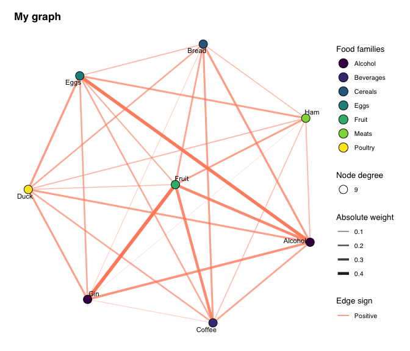

```
#>
#> $deg
#>      name degrees
#> 1 Alcohol       9
#> 2   Bread       9
#> 3  Coffee       9
#> 4    Duck       9
#> 5    Eggs       9
#> 6   Fruit       9
#> 7     Gin       9
#> 8     Ham       9
```

```r
graph1 <- graph_from_matrix(adjacency_matrix, legend, main_title = "My graph", layout = "graphopt")
graph1
```

### Or from a list of links and nodes

Useful to alter the links

```
#> $igraph
#> IGRAPH 463f605 UNW- 8 36 --
#> + attr: name (v/c), title (v/c), family (v/c), size (v/n), weight
#> | (e/n), width (e/n), sign (e/c), alpha (e/n)
#> + edges from 463f605 (vertex names):
#>  [1] alcohol_cat--alcohol_cat alcohol_cat--bread_cat   alcohol_cat--coffee_cat
#>  [4] alcohol_cat--duck_cat    alcohol_cat--eggs_cat    alcohol_cat--fruit_cat
#>  [7] alcohol_cat--gin_bin     alcohol_cat--ham_bin     bread_cat  --bread_cat
#> [10] bread_cat  --coffee_cat  bread_cat  --duck_cat    bread_cat  --eggs_cat
#> [13] bread_cat  --fruit_cat   bread_cat  --gin_bin     bread_cat  --ham_bin
#> [16] coffee_cat --coffee_cat  coffee_cat --duck_cat    coffee_cat --eggs_cat
#> [19] coffee_cat --fruit_cat   coffee_cat --gin_bin     coffee_cat --ham_bin
#> + ... omitted several edges
#>
#> $net
```

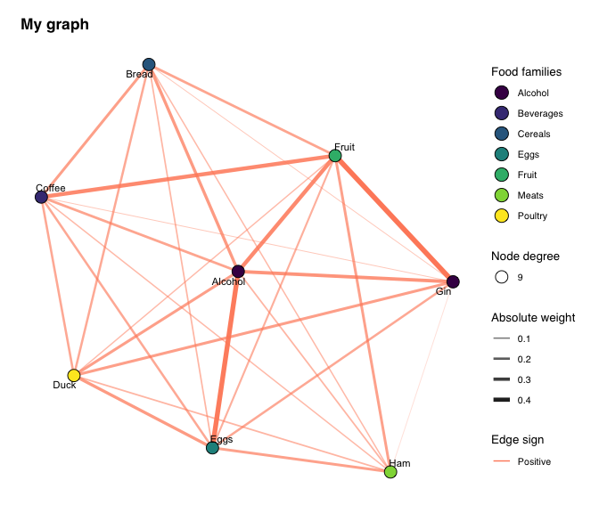

```
#>
#> $deg
#>      name degrees
#> 1 Alcohol       9
#> 2   Bread       9
#> 3  Coffee       9
#> 4    Duck       9
#> 5    Eggs       9
#> 6   Fruit       9
#> 7     Gin       9
#> 8     Ham       9
```

```r
# Extract the links and nodes from the adjacency matrix
links_nodes <- links_nodes_from_mat(adjacency_matrix, legend)

# Transform negative weights into positive ones
links_nodes$links <- transform(links_nodes$links, weight = abs(weight))

# Display the graph
graph2 <- graph_from_links_nodes(links_nodes, main_title = "My graph")
graph2
```

### Save the graph in a file

```r
save_graph(graph1)
```

### Customization

Many options and layouts exist to customize the graph.

```r
library(ggplot2)

custom1 <- graph_from_matrix(adjacency_matrix, legend, main_title = "Node label as name",
                             layout = "graphopt", node_label_title = F, node_label_size = 5)
custom2 <- graph_from_matrix(adjacency_matrix, legend, main_title = "Node type as label",
                             layout = "graphopt", node_type = "label")
custom3 <- graph_from_matrix(adjacency_matrix, legend, main_title = "Grid layout",
                             layout = "grid", node_label_size = 5)
custom4 <- graph_from_matrix(adjacency_matrix, legend, main_title = "Circle layout",
                             layout = "circle", node_label_size = 5)
```

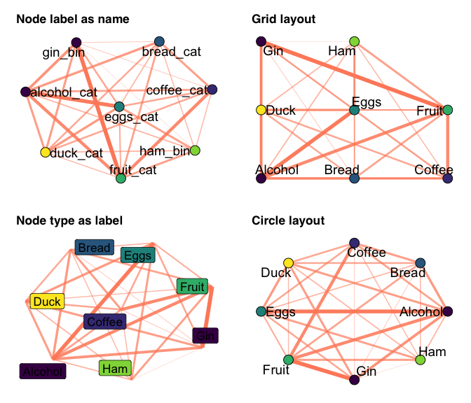

```r
custom1$net
custom2$net
custom3$net
custom4$net
```

## References

[^1]: Meyer, Patrick E, Frédéric Lafitte, and Gianluca Bontempi. “Minet: A R/Bioconductor Package for Inferring Large Transcriptional Networks Using Mutual Information.” BMC Bioinformatics 9, no. 1 (December 2008). https://doi.org/10.1186/1471-2105-9-461.
[^2]: Albanese, Davide, Michele Filosi, Roberto Visintainer, Samantha Riccadonna, Giuseppe Jurman, and Cesare Furlanello. “Minerva and Minepy: A C Engine for the MINE Suite and Its R, Python and MATLAB Wrappers.” Bioinformatics 29, no. 3 (February 1, 2013): 407–8. https://doi.org/10.1093/bioinformatics/bts707.
[^3]: H. Wickham. ggplot2: Elegant Graphics for Data Analysis. Springer-Verlag New York, 2016.
[^4]: Csardi G, Nepusz T: The igraph software package for complex network research, InterJournal, Complex Systems 1695. 2006. http://igraph.org
[^5]: Thomas Lin Pedersen, https://ggraph.data-imaginist.com/
[^6]: Albanese, Davide, Michele Filosi, Roberto Visintainer, Samantha Riccadonna, Giuseppe Jurman, and Cesare Furlanello. “Minerva and Minepy: A C Engine for the MINE Suite and Its R, Python and MATLAB Wrappers.” Bioinformatics 29, no. 3 (February 1, 2013): 407–8. https://doi.org/10.1093/bioinformatics/bts707.
[^7]: Meyer, Patrick E, Frédéric Lafitte, and Gianluca Bontempi. “Minet: A R/Bioconductor Package for Inferring Large Transcriptional Networks Using Mutual Information.” BMC Bioinformatics 9, no. 1 (December 2008). https://doi.org/10.1186/1471-2105-9-461.
[^8]: Reshef, D. N., Y. A. Reshef, H. K. Finucane, S. R. Grossman, G. McVean, P. J. Turnbaugh, E. S. Lander, M. Mitzenmacher, and P. C. Sabeti. “Detecting Novel Associations in Large Data Sets.” Science 334, no. 6062 (December 16, 2011): 1518–24. https://doi.org/10.1126/science.1205438.